[figure not shown]

# AI PROJECT 0

## Teacher: Dr. Fadaei

### Student Name: Mohammadali Shakerdargah

### Student Number: 810098002

### Purpose:

```
In this project we are going to predict a target which in this case is price of some models of cars using regression
```

### What we did in this project:

```
01- Read csv file and get desired information from it through "pandas" library and worked with 4 functions:
    1-1: "read_csv()" to read csv file.
    1-2: "head()" to get 5 first rows of our dataframe
    1-3: "tail()" to get 5 last rows of our dataframe
    1-4: "describe()" to get valuable information from our dataframe

02- Clearifying types of colomns and mapping
    2-1: Clearifying types of each colomns through "pandas" library using info()
    2-2: we map:
        - Gas to 0
        - Diesel to 1

03- Answered in 3 parts:
    3-1: Showing number of each colomn's rows that has a missing data
    3-2: We will show average of each colomn and then we will fill every colomn that has a missing data(except goal row)
         and we will make a df with only missing prices
    3-3: Another solution for each colomn's rows that has a missing data and mean method benifits

04-  We would get number of cars with specific number of cylinders

05- Count number of gas fuled cars which have more than 100 horsepower and less than 15 gallons per mile

06- Vectorization: We would get average age of the price of vehicles which use gas and diesel.

07- Loop: We would get average age of the price of vehicles which use gas and diesel.

08- Answered in 2 parts:
    8-1: In this part we are going to show the destribution of each numerical column of our dataframe.
    8-2: Showing the destribution of all numerical columns of our dataframe in one plot

09- Data normalization:
        in this method we are going to subtract all samples in a colomn from average of that colomn and then devide
        them by their standard deviation

10- Answered in 2 parts:
    10-1: Sketching scatter plot for each feature
    10-2: Deciding which feature's has the highest correlation with price and is better to be uses

11- Here we have to set a hypothesis function so that it would linearly model our regression model so that we would
    be able to predict the price of cars

12: Calculating MSE of prediced function

13: Sketching both the predicted function and the data we had earlie in one diagram

14: Final Prediction Fitting
```

## Question 1: Read csv file & get info

### Part 1-1:

```
At first we used "pandas" library and read csv file that has been given to us as "car_price_dataset.csv" and store it in
a dataframe.
```

```python
import pandas as pd
import numpy as np
df = pd.read_csv("car_price_dataset.csv")
df
```

|  | car_ID | CarName | fueltype | carlength | carwidth | carheight | curbweight | cylindernumber | enginesize | horsepower | citympg | highwaympg | price |
| --- | --- | --- | --- | --- | --- | --- | --- | --- | --- | --- | --- | --- | --- |
| 0 | 1 | alfa-romero giulia | gas | 168.8 | 64.1 | 48.8 | 2548 | four | 130.0 | 111.0 | 21 | 27 | 13495.000 |
| 1 | 2 | alfa-romero stelvio | gas | 168.8 | 64.1 | 48.8 | 2548 | four | 130.0 | 111.0 | 21 | 27 | 16500.000 |
| 2 | 3 | alfa-romero Quadrifoglio | gas | 171.2 | 65.5 | 52.4 | 2823 | six | 152.0 | 154.0 | 19 | 26 | 16500.000 |
| 3 | 4 | audi 100 ls | gas | 176.6 | 66.2 | 54.3 | 2337 | four | 109.0 | NaN | 24 | 30 | 13950.000 |
| 4 | 5 | audi 100ls | gas | 176.6 | 66.4 | 54.3 | 2824 | five | 136.0 | 115.0 | 18 | 22 | NaN |
| 5 | 6 | audi fox | gas | 177.3 | 66.3 | 53.1 | 2507 | five | 136.0 | 110.0 | 19 | 25 | 15250.000 |
| 6 | 7 | audi 100ls | gas | 192.7 | 71.4 | 55.7 | 2844 | five | 136.0 | 110.0 | 19 | 25 | 17710.000 |
| 7 | 8 | audi 5000 | gas | 192.7 | 71.4 | 55.7 | 2954 | five | 136.0 | 110.0 | 19 | 25 | 18920.000 |
| 8 | 9 | audi 4000 | gas | 192.7 | 71.4 | 55.9 | 3086 | five | 131.0 | 140.0 | 17 | 20 | 23875.000 |
| 9 | 10 | audi 5000s (diesel) | gas | 178.2 | 67.9 | 52.0 | 3053 | five | 131.0 | NaN | 16 | 22 | 17859.167 |
| 10 | 11 | bmw 320i | gas | 176.8 | 64.8 | 54.3 | 2395 | four | 108.0 | 101.0 | 23 | 29 | 16430.000 |
| 11 | 12 | bmw 320i | gas | 176.8 | 64.8 | 54.3 | 2395 | four | 108.0 | NaN | 23 | 29 | 16925.000 |
| 12 | 13 | bmw x1 | gas | 176.8 | 64.8 | 54.3 | 2710 | six | 164.0 | 121.0 | 21 | 28 | 20970.000 |
| 13 | 14 | bmw x3 | gas | 176.8 | 64.8 | 54.3 | 2765 | six | 164.0 | 121.0 | 21 | 28 | 21105.000 |
| 14 | 15 | bmw z4 | gas | 189.0 | 66.9 | 55.7 | 3055 | six | 164.0 | 121.0 | 20 | 25 | 24565.000 |
| 15 | 16 | bmw x4 | gas | 189.0 | 66.9 | 55.7 | 3230 | six | 209.0 | 182.0 | 16 | 22 | 30760.000 |
| 16 | 17 | bmw x5 | gas | 193.8 | 67.9 | 53.7 | 3380 | six | 209.0 | 182.0 | 16 | 22 | 41315.000 |
| 17 | 18 | bmw x3 | gas | 197.0 | 70.9 | 56.3 | 3505 | six | NaN | 182.0 | 15 | 20 | 36880.000 |
| 18 | 19 | chevrolet impala | gas | 141.1 | 60.3 | 53.2 | 1488 | three | 61.0 | NaN | 47 | 53 | 5151.000 |
| 19 | 20 | chevrolet monte carlo | gas | 155.9 | 63.6 | 52.0 | 1874 | four | 90.0 | 70.0 | 38 | 43 | 6295.000 |
| 20 | 21 | chevrolet vega 2300 | gas | 158.8 | 63.6 | 52.0 | 1909 | four | 90.0 | 70.0 | 38 | 43 | 6575.000 |
| 21 | 22 | dodge rampage | gas | 157.3 | 63.8 | 50.8 | 1876 | four | NaN | 68.0 | 37 | 41 | 5572.000 |
| 22 | 23 | dodge challenger se | gas | 157.3 | 63.8 | 50.8 | 1876 | four | 90.0 | 68.0 | 31 | 38 | 6377.000 |
| 23 | 24 | dodge d200 | gas | 157.3 | 63.8 | 50.8 | 2128 | four | 98.0 | 102.0 | 24 | 30 | 7957.000 |
| 24 | 25 | dodge monaco (sw) | gas | 157.3 | 63.8 | 50.6 | 1967 | four | 90.0 | 68.0 | 31 | 38 | 6229.000 |
| 25 | 26 | dodge colt hardtop | gas | 157.3 | 63.8 | 50.6 | 1989 | four | 90.0 | NaN | 31 | 38 | 6692.000 |
| 26 | 27 | dodge colt (sw) | gas | 157.3 | 63.8 | 50.6 | 1989 | four | 90.0 | 68.0 | 31 | 38 | 7609.000 |
| 27 | 28 | dodge coronet custom | gas | 157.3 | 63.8 | 50.6 | 2191 | four | 98.0 | 102.0 | 24 | 30 | 8558.000 |
| 28 | 29 | dodge dart custom | gas | 174.6 | 64.6 | 59.8 | 2535 | four | 122.0 | 88.0 | 24 | 30 | 8921.000 |
| 29 | 30 | dodge coronet custom (sw) | gas | 173.2 | 66.3 | 50.2 | 2811 | four | 156.0 | 145.0 | 19 | 24 | NaN |
| ... | ... | ... | ... | ... | ... | ... | ... | ... | ... | ... | ... | ... | ... |
| 175 | 176 | toyota corona | gas | 175.6 | 66.5 | 53.9 | 2414 | four | 122.0 | 92.0 | 27 | 32 | 9988.000 |
| 176 | 177 | toyota corolla | gas | 175.6 | 66.5 | 54.9 | 2414 | four | NaN | 92.0 | 27 | 32 | 10898.000 |
| 177 | 178 | toyota mark ii | gas | 175.6 | 66.5 | 53.9 | 2458 | four | 122.0 | 92.0 | 27 | 32 | 11248.000 |
| 178 | 179 | toyota corolla liftback | gas | 183.5 | 67.7 | 52.0 | 2976 | six | 171.0 | 161.0 | 20 | 24 | 16558.000 |
| 179 | 180 | toyota corona | gas | 183.5 | 67.7 | 52.0 | 3016 | six | NaN | 161.0 | 19 | 24 | 15998.000 |
| 180 | 181 | toyota starlet | gas | 187.8 | 66.5 | 54.1 | 3131 | six | 171.0 | 156.0 | 20 | 24 | 15690.000 |
| 181 | 182 | toyouta tercel | gas | 187.8 | 66.5 | 54.1 | 3151 | six | 161.0 | 156.0 | 19 | 24 | NaN |
| 182 | 183 | vokswagen rabbit | diesel | 171.7 | 65.5 | 55.7 | 2261 | four | 97.0 | 52.0 | 37 | 46 | 7775.000 |
| 183 | 184 | volkswagen 1131 deluxe sedan | gas | 171.7 | 65.5 | 55.7 | 2209 | four | 109.0 | 85.0 | 27 | 34 | 7975.000 |
| 184 | 185 | volkswagen model 111 | diesel | 171.7 | 65.5 | 55.7 | 2264 | four | 97.0 | 52.0 | 37 | 46 | 7995.000 |
| 185 | 186 | volkswagen type 3 | gas | 171.7 | 65.5 | 55.7 | 2212 | four | 109.0 | 85.0 | 27 | 34 | 8195.000 |
| 186 | 187 | volkswagen 411 (sw) | gas | 171.7 | 65.5 | 55.7 | 2275 | four | 109.0 | 85.0 | 27 | 34 | 8495.000 |
| 187 | 188 | volkswagen super beetle | diesel | 171.7 | 65.5 | 55.7 | 2319 | four | 97.0 | 68.0 | 37 | 42 | 9495.000 |
| 188 | 189 | volkswagen dasher | gas | 171.7 | 65.5 | 55.7 | 2300 | four | 109.0 | 100.0 | 26 | 32 | 9995.000 |
| 189 | 190 | vw dasher | gas | 159.3 | 64.2 | 55.6 | 2254 | four | 109.0 | 90.0 | 24 | 29 | NaN |
| 190 | 191 | vw rabbit | gas | 165.7 | 64.0 | 51.4 | 2221 | four | 109.0 | 90.0 | 24 | 29 | 9980.000 |
| 191 | 192 | volkswagen rabbit | gas | 180.2 | 66.9 | 55.1 | 2661 | five | 136.0 | NaN | 19 | 24 | 13295.000 |
| 192 | 193 | volkswagen rabbit custom | diesel | 180.2 | 66.9 | 55.1 | 2579 | four | 97.0 | 68.0 | 33 | 38 | 13845.000 |
| 193 | 194 | volkswagen dasher | gas | 183.1 | 66.9 | 55.1 | 2563 | four | 109.0 | 88.0 | 25 | 31 | 12290.000 |
| 194 | 195 | volvo 145e (sw) | gas | 188.8 | 67.2 | 56.2 | 2912 | four | 141.0 | 114.0 | 23 | 28 | 12940.000 |
| 195 | 196 | volvo 144ea | gas | 188.8 | 67.2 | 57.5 | 3034 | four | 141.0 | 114.0 | 23 | 28 | 13415.000 |
| 196 | 197 | volvo 244dl | gas | 188.8 | 67.2 | 56.2 | 2935 | four | 141.0 | 114.0 | 24 | 28 | 15985.000 |
| 197 | 198 | volvo 245 | gas | 188.8 | 67.2 | 57.5 | 3042 | four | 141.0 | 114.0 | 24 | 28 | 16515.000 |
| 198 | 199 | volvo 264gl | gas | 188.8 | 67.2 | 56.2 | 3045 | four | 130.0 | 162.0 | 17 | 22 | 18420.000 |
| 199 | 200 | volvo diesel | gas | 188.8 | 67.2 | 57.5 | 3157 | four | 130.0 | 162.0 | 17 | 22 | 18950.000 |
| 200 | 201 | volvo 145e (sw) | gas | 188.8 | 68.9 | 55.5 | 2952 | four | 141.0 | 114.0 | 23 | 28 | 16845.000 |
| 201 | 202 | volvo 144ea | gas | 188.8 | 68.8 | 55.5 | 3049 | four | 141.0 | 160.0 | 19 | 25 | 19045.000 |
| 202 | 203 | volvo 244dl | gas | 188.8 | 68.9 | 55.5 | 3012 | six | 173.0 | 134.0 | 18 | 23 | 21485.000 |
| 203 | 204 | volvo 246 | diesel | 188.8 | 68.9 | 55.5 | 3217 | six | 145.0 | 106.0 | 26 | 27 | 22470.000 |
| 204 | 205 | volvo 264gl | gas | 188.8 | 68.9 | 55.5 | 3062 | four | 141.0 | 114.0 | 19 | 25 | 22625.000 |

205 rows × 13 columns

### Part 1-2:

```
we used "pandas" library and use "head()" function to get 5 first rows of our dataframe
```

```python
df.head()
```

|  | car_ID | CarName | fueltype | carlength | carwidth | carheight | curbweight | cylindernumber | enginesize | horsepower | citympg | highwaympg | price |
| --- | --- | --- | --- | --- | --- | --- | --- | --- | --- | --- | --- | --- | --- |
| 0 | 1 | alfa-romero giulia | gas | 168.8 | 64.1 | 48.8 | 2548 | four | 130.0 | 111.0 | 21 | 27 | 13495.0 |
| 1 | 2 | alfa-romero stelvio | gas | 168.8 | 64.1 | 48.8 | 2548 | four | 130.0 | 111.0 | 21 | 27 | 16500.0 |
| 2 | 3 | alfa-romero Quadrifoglio | gas | 171.2 | 65.5 | 52.4 | 2823 | six | 152.0 | 154.0 | 19 | 26 | 16500.0 |
| 3 | 4 | audi 100 ls | gas | 176.6 | 66.2 | 54.3 | 2337 | four | 109.0 | NaN | 24 | 30 | 13950.0 |
| 4 | 5 | audi 100ls | gas | 176.6 | 66.4 | 54.3 | 2824 | five | 136.0 | 115.0 | 18 | 22 | NaN |

### Part 1-3:

```
we used "pandas" library and use "tail()" function to get 5 last rows of our dataframe
```

```python
df.tail()
```

|  | car_ID | CarName | fueltype | carlength | carwidth | carheight | curbweight | cylindernumber | enginesize | horsepower | citympg | highwaympg | price |
| --- | --- | --- | --- | --- | --- | --- | --- | --- | --- | --- | --- | --- | --- |
| 200 | 201 | volvo 145e (sw) | gas | 188.8 | 68.9 | 55.5 | 2952 | four | 141.0 | 114.0 | 23 | 28 | 16845.0 |
| 201 | 202 | volvo 144ea | gas | 188.8 | 68.8 | 55.5 | 3049 | four | 141.0 | 160.0 | 19 | 25 | 19045.0 |
| 202 | 203 | volvo 244dl | gas | 188.8 | 68.9 | 55.5 | 3012 | six | 173.0 | 134.0 | 18 | 23 | 21485.0 |
| 203 | 204 | volvo 246 | diesel | 188.8 | 68.9 | 55.5 | 3217 | six | 145.0 | 106.0 | 26 | 27 | 22470.0 |
| 204 | 205 | volvo 264gl | gas | 188.8 | 68.9 | 55.5 | 3062 | four | 141.0 | 114.0 | 19 | 25 | 22625.0 |

### Part 1-4:

```
we used "pandas" library and use "describe()" to get valuable information from our dataframe, after running it, for the colomns that are not categorical, we would have every colomn's:
    1- Mean
    2- Standard deviation
    3- Minimum
    4- 25%, 50% and 75% The percentiles to include in the output.
    5- Maximum
```

```python
df.describe()
```

|  | car_ID | carlength | carwidth | carheight | curbweight | enginesize | horsepower | citympg | highwaympg | price |
| --- | --- | --- | --- | --- | --- | --- | --- | --- | --- | --- |
| count | 205.000000 | 205.000000 | 205.000000 | 205.000000 | 205.000000 | 191.000000 | 182.000000 | 205.000000 | 205.000000 | 185.000000 |
| mean | 103.000000 | 174.049268 | 65.907805 | 53.724878 | 2555.565854 | 125.418848 | 105.747253 | 25.219512 | 30.751220 | 13392.181984 |
| std | 59.322565 | 12.337289 | 2.145204 | 2.443522 | 520.680204 | 39.229587 | 40.288214 | 6.542142 | 6.886443 | 8235.838288 |
| min | 1.000000 | 141.100000 | 60.300000 | 47.800000 | 1488.000000 | 61.000000 | 52.000000 | 13.000000 | 16.000000 | 5118.000000 |
| 25% | 52.000000 | 166.300000 | 64.100000 | 52.000000 | 2145.000000 | 97.000000 | 72.250000 | 19.000000 | 25.000000 | 7788.000000 |
| 50% | 103.000000 | 173.200000 | 65.500000 | 54.100000 | 2414.000000 | 119.000000 | 95.000000 | 24.000000 | 30.000000 | 10295.000000 |
| 75% | 154.000000 | 183.100000 | 66.900000 | 55.500000 | 2935.000000 | 141.000000 | 121.000000 | 30.000000 | 34.000000 | 16503.000000 |
| max | 205.000000 | 208.100000 | 72.300000 | 59.800000 | 4066.000000 | 326.000000 | 288.000000 | 49.000000 | 54.000000 | 45400.000000 |

## Question 2: Clearifying types of colomns and mapping

### Part 2-1:

```
Here is where we clearify types of each colomns through "pandas" library using info() which gives us:
    1- RangeIndex
    2- Range of colomns
    3- Type of each colomn
    4- Memory usage
```

```python
df.info()
```

```
<class 'pandas.core.frame.DataFrame'>
RangeIndex: 205 entries, 0 to 204
Data columns (total 13 columns):
car_ID            205 non-null int64
CarName           205 non-null object
fueltype          205 non-null object
carlength         205 non-null float64
carwidth          205 non-null float64
carheight         205 non-null float64
curbweight        205 non-null int64
cylindernumber    205 non-null object
enginesize        191 non-null float64
horsepower        182 non-null float64
citympg           205 non-null int64
highwaympg        205 non-null int64
price             185 non-null float64
dtypes: float64(6), int64(4), object(3)
memory usage: 20.9+ KB
```

### Part 2-2:

```
Here is where for a better process, we map:
    - Gas to 0
    - Diesel to 1
```

```python
replaceFueltype = {"gas":0, "diesel":1}
df["fueltype"] = df["fueltype"].map(replaceFueltype)
df
```

|  | car_ID | CarName | fueltype | carlength | carwidth | carheight | curbweight | cylindernumber | enginesize | horsepower | citympg | highwaympg | price |
| --- | --- | --- | --- | --- | --- | --- | --- | --- | --- | --- | --- | --- | --- |
| 0 | 1 | alfa-romero giulia | 0 | 168.8 | 64.1 | 48.8 | 2548 | four | 130.0 | 111.0 | 21 | 27 | 13495.000 |
| 1 | 2 | alfa-romero stelvio | 0 | 168.8 | 64.1 | 48.8 | 2548 | four | 130.0 | 111.0 | 21 | 27 | 16500.000 |
| 2 | 3 | alfa-romero Quadrifoglio | 0 | 171.2 | 65.5 | 52.4 | 2823 | six | 152.0 | 154.0 | 19 | 26 | 16500.000 |
| 3 | 4 | audi 100 ls | 0 | 176.6 | 66.2 | 54.3 | 2337 | four | 109.0 | NaN | 24 | 30 | 13950.000 |
| 4 | 5 | audi 100ls | 0 | 176.6 | 66.4 | 54.3 | 2824 | five | 136.0 | 115.0 | 18 | 22 | NaN |
| 5 | 6 | audi fox | 0 | 177.3 | 66.3 | 53.1 | 2507 | five | 136.0 | 110.0 | 19 | 25 | 15250.000 |
| 6 | 7 | audi 100ls | 0 | 192.7 | 71.4 | 55.7 | 2844 | five | 136.0 | 110.0 | 19 | 25 | 17710.000 |
| 7 | 8 | audi 5000 | 0 | 192.7 | 71.4 | 55.7 | 2954 | five | 136.0 | 110.0 | 19 | 25 | 18920.000 |
| 8 | 9 | audi 4000 | 0 | 192.7 | 71.4 | 55.9 | 3086 | five | 131.0 | 140.0 | 17 | 20 | 23875.000 |
| 9 | 10 | audi 5000s (diesel) | 0 | 178.2 | 67.9 | 52.0 | 3053 | five | 131.0 | NaN | 16 | 22 | 17859.167 |
| 10 | 11 | bmw 320i | 0 | 176.8 | 64.8 | 54.3 | 2395 | four | 108.0 | 101.0 | 23 | 29 | 16430.000 |
| 11 | 12 | bmw 320i | 0 | 176.8 | 64.8 | 54.3 | 2395 | four | 108.0 | NaN | 23 | 29 | 16925.000 |
| 12 | 13 | bmw x1 | 0 | 176.8 | 64.8 | 54.3 | 2710 | six | 164.0 | 121.0 | 21 | 28 | 20970.000 |
| 13 | 14 | bmw x3 | 0 | 176.8 | 64.8 | 54.3 | 2765 | six | 164.0 | 121.0 | 21 | 28 | 21105.000 |
| 14 | 15 | bmw z4 | 0 | 189.0 | 66.9 | 55.7 | 3055 | six | 164.0 | 121.0 | 20 | 25 | 24565.000 |
| 15 | 16 | bmw x4 | 0 | 189.0 | 66.9 | 55.7 | 3230 | six | 209.0 | 182.0 | 16 | 22 | 30760.000 |
| 16 | 17 | bmw x5 | 0 | 193.8 | 67.9 | 53.7 | 3380 | six | 209.0 | 182.0 | 16 | 22 | 41315.000 |
| 17 | 18 | bmw x3 | 0 | 197.0 | 70.9 | 56.3 | 3505 | six | NaN | 182.0 | 15 | 20 | 36880.000 |
| 18 | 19 | chevrolet impala | 0 | 141.1 | 60.3 | 53.2 | 1488 | three | 61.0 | NaN | 47 | 53 | 5151.000 |
| 19 | 20 | chevrolet monte carlo | 0 | 155.9 | 63.6 | 52.0 | 1874 | four | 90.0 | 70.0 | 38 | 43 | 6295.000 |
| 20 | 21 | chevrolet vega 2300 | 0 | 158.8 | 63.6 | 52.0 | 1909 | four | 90.0 | 70.0 | 38 | 43 | 6575.000 |
| 21 | 22 | dodge rampage | 0 | 157.3 | 63.8 | 50.8 | 1876 | four | NaN | 68.0 | 37 | 41 | 5572.000 |
| 22 | 23 | dodge challenger se | 0 | 157.3 | 63.8 | 50.8 | 1876 | four | 90.0 | 68.0 | 31 | 38 | 6377.000 |
| 23 | 24 | dodge d200 | 0 | 157.3 | 63.8 | 50.8 | 2128 | four | 98.0 | 102.0 | 24 | 30 | 7957.000 |
| 24 | 25 | dodge monaco (sw) | 0 | 157.3 | 63.8 | 50.6 | 1967 | four | 90.0 | 68.0 | 31 | 38 | 6229.000 |
| 25 | 26 | dodge colt hardtop | 0 | 157.3 | 63.8 | 50.6 | 1989 | four | 90.0 | NaN | 31 | 38 | 6692.000 |
| 26 | 27 | dodge colt (sw) | 0 | 157.3 | 63.8 | 50.6 | 1989 | four | 90.0 | 68.0 | 31 | 38 | 7609.000 |
| 27 | 28 | dodge coronet custom | 0 | 157.3 | 63.8 | 50.6 | 2191 | four | 98.0 | 102.0 | 24 | 30 | 8558.000 |
| 28 | 29 | dodge dart custom | 0 | 174.6 | 64.6 | 59.8 | 2535 | four | 122.0 | 88.0 | 24 | 30 | 8921.000 |
| 29 | 30 | dodge coronet custom (sw) | 0 | 173.2 | 66.3 | 50.2 | 2811 | four | 156.0 | 145.0 | 19 | 24 | NaN |
| ... | ... | ... | ... | ... | ... | ... | ... | ... | ... | ... | ... | ... | ... |
| 175 | 176 | toyota corona | 0 | 175.6 | 66.5 | 53.9 | 2414 | four | 122.0 | 92.0 | 27 | 32 | 9988.000 |
| 176 | 177 | toyota corolla | 0 | 175.6 | 66.5 | 54.9 | 2414 | four | NaN | 92.0 | 27 | 32 | 10898.000 |
| 177 | 178 | toyota mark ii | 0 | 175.6 | 66.5 | 53.9 | 2458 | four | 122.0 | 92.0 | 27 | 32 | 11248.000 |
| 178 | 179 | toyota corolla liftback | 0 | 183.5 | 67.7 | 52.0 | 2976 | six | 171.0 | 161.0 | 20 | 24 | 16558.000 |
| 179 | 180 | toyota corona | 0 | 183.5 | 67.7 | 52.0 | 3016 | six | NaN | 161.0 | 19 | 24 | 15998.000 |
| 180 | 181 | toyota starlet | 0 | 187.8 | 66.5 | 54.1 | 3131 | six | 171.0 | 156.0 | 20 | 24 | 15690.000 |
| 181 | 182 | toyouta tercel | 0 | 187.8 | 66.5 | 54.1 | 3151 | six | 161.0 | 156.0 | 19 | 24 | NaN |
| 182 | 183 | vokswagen rabbit | 1 | 171.7 | 65.5 | 55.7 | 2261 | four | 97.0 | 52.0 | 37 | 46 | 7775.000 |
| 183 | 184 | volkswagen 1131 deluxe sedan | 0 | 171.7 | 65.5 | 55.7 | 2209 | four | 109.0 | 85.0 | 27 | 34 | 7975.000 |
| 184 | 185 | volkswagen model 111 | 1 | 171.7 | 65.5 | 55.7 | 2264 | four | 97.0 | 52.0 | 37 | 46 | 7995.000 |
| 185 | 186 | volkswagen type 3 | 0 | 171.7 | 65.5 | 55.7 | 2212 | four | 109.0 | 85.0 | 27 | 34 | 8195.000 |
| 186 | 187 | volkswagen 411 (sw) | 0 | 171.7 | 65.5 | 55.7 | 2275 | four | 109.0 | 85.0 | 27 | 34 | 8495.000 |
| 187 | 188 | volkswagen super beetle | 1 | 171.7 | 65.5 | 55.7 | 2319 | four | 97.0 | 68.0 | 37 | 42 | 9495.000 |
| 188 | 189 | volkswagen dasher | 0 | 171.7 | 65.5 | 55.7 | 2300 | four | 109.0 | 100.0 | 26 | 32 | 9995.000 |
| 189 | 190 | vw dasher | 0 | 159.3 | 64.2 | 55.6 | 2254 | four | 109.0 | 90.0 | 24 | 29 | NaN |
| 190 | 191 | vw rabbit | 0 | 165.7 | 64.0 | 51.4 | 2221 | four | 109.0 | 90.0 | 24 | 29 | 9980.000 |
| 191 | 192 | volkswagen rabbit | 0 | 180.2 | 66.9 | 55.1 | 2661 | five | 136.0 | NaN | 19 | 24 | 13295.000 |
| 192 | 193 | volkswagen rabbit custom | 1 | 180.2 | 66.9 | 55.1 | 2579 | four | 97.0 | 68.0 | 33 | 38 | 13845.000 |
| 193 | 194 | volkswagen dasher | 0 | 183.1 | 66.9 | 55.1 | 2563 | four | 109.0 | 88.0 | 25 | 31 | 12290.000 |
| 194 | 195 | volvo 145e (sw) | 0 | 188.8 | 67.2 | 56.2 | 2912 | four | 141.0 | 114.0 | 23 | 28 | 12940.000 |
| 195 | 196 | volvo 144ea | 0 | 188.8 | 67.2 | 57.5 | 3034 | four | 141.0 | 114.0 | 23 | 28 | 13415.000 |
| 196 | 197 | volvo 244dl | 0 | 188.8 | 67.2 | 56.2 | 2935 | four | 141.0 | 114.0 | 24 | 28 | 15985.000 |
| 197 | 198 | volvo 245 | 0 | 188.8 | 67.2 | 57.5 | 3042 | four | 141.0 | 114.0 | 24 | 28 | 16515.000 |
| 198 | 199 | volvo 264gl | 0 | 188.8 | 67.2 | 56.2 | 3045 | four | 130.0 | 162.0 | 17 | 22 | 18420.000 |
| 199 | 200 | volvo diesel | 0 | 188.8 | 67.2 | 57.5 | 3157 | four | 130.0 | 162.0 | 17 | 22 | 18950.000 |
| 200 | 201 | volvo 145e (sw) | 0 | 188.8 | 68.9 | 55.5 | 2952 | four | 141.0 | 114.0 | 23 | 28 | 16845.000 |
| 201 | 202 | volvo 144ea | 0 | 188.8 | 68.8 | 55.5 | 3049 | four | 141.0 | 160.0 | 19 | 25 | 19045.000 |
| 202 | 203 | volvo 244dl | 0 | 188.8 | 68.9 | 55.5 | 3012 | six | 173.0 | 134.0 | 18 | 23 | 21485.000 |
| 203 | 204 | volvo 246 | 1 | 188.8 | 68.9 | 55.5 | 3217 | six | 145.0 | 106.0 | 26 | 27 | 22470.000 |
| 204 | 205 | volvo 264gl | 0 | 188.8 | 68.9 | 55.5 | 3062 | four | 141.0 | 114.0 | 19 | 25 | 22625.000 |

205 rows × 13 columns

## Question 3: Missing Datas and Solutions

### Part 3-1:

```
Showing all the rows of each colomn that has a missing data (has "NaN" inside it) using isna() method and we have to sum it up.
```

```python
df.isna().sum()
```

```
car_ID             0
CarName            0
fueltype           0
carlength          0
carwidth           0
carheight          0
curbweight         0
cylindernumber     0
enginesize        14
horsepower        23
citympg            0
highwaympg         0
price             20
dtype: int64
```

```
so it has 14 missing datas in enginesize colomn and 23 missing datas in horsepower colomn (and 20 missing datas in
price colomn)
```

### Part 3-2:

```
we will show average of each colomn and then we will fill every colomn that has a missing data with the average of that
colomn and we will show that all of them are filled except the goal colomn.
we will make a df with only missing prices
```

```python
df.mean()
```

```
car_ID          103.000000
fueltype          0.097561
carlength       174.049268
carwidth         65.907805
carheight        53.724878
curbweight     2555.565854
enginesize      125.418848
horsepower      105.747253
citympg          25.219512
highwaympg       30.751220
price         13392.181984
dtype: float64
```

```python
dfFilled = df.copy()
meanEnginesize = dfFilled["enginesize"].mean()
dfFilled["enginesize"] = dfFilled["enginesize"].fillna(meanEnginesize)
meanEnginesize = dfFilled["horsepower"].mean()
dfFilled["horsepower"] = dfFilled["horsepower"].fillna(meanEnginesize)
dfFilled.isna().sum()
```

```
car_ID             0
CarName            0
fueltype           0
carlength          0
carwidth           0
carheight          0
curbweight         0
cylindernumber     0
enginesize         0
horsepower         0
citympg            0
highwaympg         0
price             20
dtype: int64
```

```python
dfWithMissingPrice = df[df["price"].isnull()].copy()
carID_NANPrice = dfWithMissingPrice["car_ID"].tolist()
dfWithMissingPrice
```

|  | car_ID | CarName | fueltype | carlength | carwidth | carheight | curbweight | cylindernumber | enginesize | horsepower | citympg | highwaympg | price |
| --- | --- | --- | --- | --- | --- | --- | --- | --- | --- | --- | --- | --- | --- |
| 4 | 5 | audi 100ls | 0 | 176.6 | 66.4 | 54.3 | 2824 | five | 136.0 | 115.0 | 18 | 22 | NaN |
| 29 | 30 | dodge coronet custom (sw) | 0 | 173.2 | 66.3 | 50.2 | 2811 | four | 156.0 | 145.0 | 19 | 24 | NaN |
| 31 | 32 | honda civic cvcc | 0 | 144.6 | 63.9 | 50.8 | 1819 | four | 92.0 | 76.0 | 31 | 38 | NaN |
| 52 | 53 | mazda rx2 coupe | 0 | 159.1 | 64.2 | 54.1 | 1905 | four | 91.0 | 68.0 | 31 | 38 | NaN |
| 53 | 54 | mazda rx-4 | 0 | 166.8 | 64.2 | 54.1 | 1945 | four | 91.0 | 68.0 | 31 | 38 | NaN |
| 59 | 60 | mazda 626 | 0 | 177.8 | 66.5 | 53.7 | 2385 | four | 122.0 | 84.0 | 26 | 32 | NaN |
| 62 | 63 | mazda rx-4 | 0 | 177.8 | 66.5 | 55.5 | 2410 | four | 122.0 | 84.0 | 26 | 32 | NaN |
| 67 | 68 | buick electra 225 custom | 1 | 190.9 | 70.3 | 56.5 | 3515 | five | 183.0 | 123.0 | 22 | 25 | NaN |
| 78 | 79 | mitsubishi outlander | 0 | 157.3 | 64.4 | 50.8 | 2004 | four | 92.0 | 68.0 | 31 | 38 | NaN |
| 84 | 85 | mitsubishi mirage g4 | 0 | 173.2 | 66.3 | 50.2 | 2926 | four | 156.0 | 145.0 | 19 | 24 | NaN |
| 87 | 88 | mitsubishi outlander | 0 | 172.4 | 65.4 | 51.6 | 2403 | four | 110.0 | 116.0 | 23 | 30 | NaN |
| 88 | 89 | mitsubishi mirage g4 | 0 | 172.4 | 65.4 | 51.6 | 2403 | four | 110.0 | 116.0 | 23 | 30 | NaN |
| 104 | 105 | nissan teana | 0 | 170.7 | 67.9 | 49.7 | 3071 | six | 181.0 | 160.0 | 19 | 25 | NaN |
| 123 | 124 | plymouth valiant | 0 | 174.6 | 64.6 | 59.8 | 2535 | four | 122.0 | 88.0 | 24 | 30 | NaN |
| 136 | 137 | saab 99gle | 0 | 186.6 | 66.5 | 56.1 | 2808 | four | NaN | 160.0 | 19 | 26 | NaN |
| 137 | 138 | saab 99e | 0 | 186.6 | 66.5 | 56.1 | 2847 | four | 121.0 | 160.0 | 19 | 26 | NaN |
| 141 | 142 | subaru | 0 | 172.0 | 65.4 | 52.5 | 2145 | four | 108.0 | 82.0 | 32 | 37 | NaN |
| 149 | 150 | subaru dl | 0 | 173.6 | 65.4 | 54.9 | 2650 | four | 108.0 | 111.0 | 23 | 23 | NaN |
| 181 | 182 | toyouta tercel | 0 | 187.8 | 66.5 | 54.1 | 3151 | six | 161.0 | 156.0 | 19 | 24 | NaN |
| 189 | 190 | vw dasher | 0 | 159.3 | 64.2 | 55.6 | 2254 | four | 109.0 | 90.0 | 24 | 29 | NaN |

## Question 3:

### Part 3-3:

[output not shown]

## Question 4: Number of cars with specific number of cylinders

```python
cylindernumbers = list(dfFilled.cylindernumber.unique())
numCarBasedOnNumCylinder = []
for i in range(len(cylindernumbers)):
    counted = np.where(dfFilled['cylindernumber'] == cylindernumbers[i])
    numCarBasedOnNumCylinder.append(len(counted[0]))
for i in range(len(cylindernumbers)):
    print("Number of cars with",cylindernumbers[i],"Cylinders: ",numCarBasedOnNumCylinder[i])
print("Total:",np.sum(numCarBasedOnNumCylinder))
```

```
Number of cars with four Cylinders:  159
Number of cars with six Cylinders:  24
Number of cars with five Cylinders:  11
Number of cars with three Cylinders:  1
Number of cars with twelve Cylinders:  1
Number of cars with two Cylinders:  4
Number of cars with eight Cylinders:  5
Total: 205
```

## Question 5: Number of gas fuled cars with condition

```
  Count number of gas fuled cars which have more than 100 horsepower and less than 15 gallons per mile
```

```python
conditions = [ ( dfFilled["fueltype"] == 0 ) & ( dfFilled["horsepower"]>100 ) & ( dfFilled["citympg"]<15 ) ]
choices     = ['target']
result = np.select(conditions, choices)
result = np.where(result== 'target')
print("Number of selected Cars", len(result[0]))
```

```
Number of selected Cars 3
```

## Question 6: Average with vectorization

```
Vectorization: We would get average age of the price of vehicles which use gas and diesel.
```

```python
import time
tic = time.time()

result = np.select([(dfFilled['fueltype'] == 0)],['target']) #Gas
result = np.where(result== 'target')
avgPriceGas = dfFilled.iloc[result[0],12].mean()

result = np.select([(dfFilled['fueltype'] == 1)],['target']) #Diesel
result = np.where(result== 'target')
avgPriceDiesel = dfFilled.iloc[result[0],12].mean()

toc = time.time()
print("for Vectorization: %f ms" %((toc-tic)*1000))
print("avgPriceGas: ", avgPriceGas)
print("avgPriceDiesel: ", avgPriceDiesel)
```

```
for Vectorization: 1.000166 ms
avgPriceGas:  13170.738957831325
avgPriceDiesel:  15326.894736842105
```

## Question 7: Average with loop

[output not shown]

```python
tic = time.time()

sumPriceGas =0
numPriceGas =0
sumPriceDiesel =0
numPriceDiesel =0
for index, row in dfFilled.iterrows():
    if row['fueltype'] == 0 and ((index+1) not in carID_NANPrice):
        sumPriceGas = sumPriceGas + row['price']
        numPriceGas = numPriceGas+1
    elif row['fueltype'] == 1 and ((index+1) not in carID_NANPrice):
        sumPriceDiesel = sumPriceDiesel + row['price']
        numPriceDiesel = numPriceDiesel+1
toc = time.time()
print("for loop: %f ms" %((toc-tic)*1000))
print("avgPriceGas: ", sumPriceGas/numPriceGas)
print("avgPriceDiesel: ", sumPriceDiesel/numPriceDiesel)
```

```
for loop: 12.996912 ms
avgPriceGas:  13170.738957831325
avgPriceDiesel:  15326.894736842105
```

We can totally see that vectorization helps us to make our code more efficient both in timing and also the number of lines that we use.

## Question 8: Distributions and Plots

### Part 8-1:

```
In this part we are going to show the destribution of each column of our dataframe
```

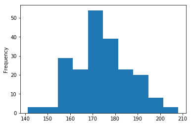

```python
import matplotlib as plot
dfFilled["carlength"].plot.hist()
```

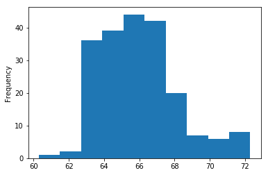

```python
dfFilled["carwidth"].plot.hist()
```

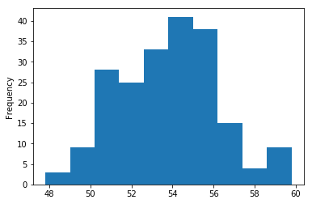

```python
dfFilled["carheight"].plot.hist()
```

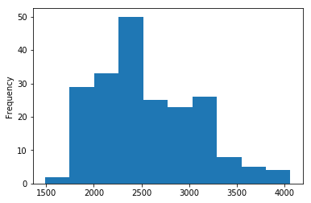

```python
dfFilled["curbweight"].plot.hist()
```

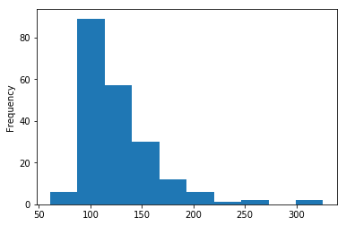

```python
dfFilled["enginesize"].plot.hist()
```

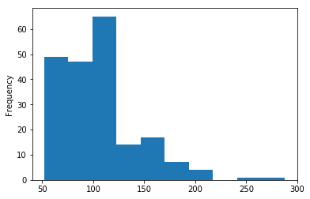

```python
dfFilled["horsepower"].plot.hist()
```

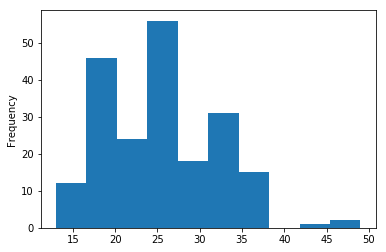

```python
dfFilled["citympg"].plot.hist()
```

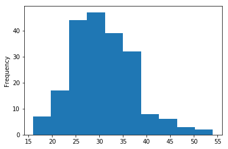

```python
dfFilled["highwaympg"].plot.hist()
```

### Part 8-2:

```
Showing the destribution of all columns of our dataframe in one plot
```

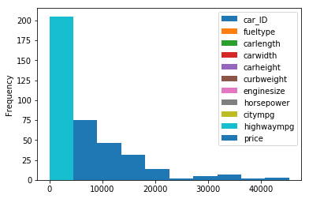

```python
dfFilled.plot.hist()
```

## Question 9: Data normalization:

```
    in this method we are going to subtract all samples in a colomn from average of that colomn and then devide
    them by their standard deviation
```

```python
dfFilled
```

|  | car_ID | CarName | fueltype | carlength | carwidth | carheight | curbweight | cylindernumber | enginesize | horsepower | citympg | highwaympg | price |
| --- | --- | --- | --- | --- | --- | --- | --- | --- | --- | --- | --- | --- | --- |
| 0 | 1 | alfa-romero giulia | 0 | 168.8 | 64.1 | 48.8 | 2548 | four | 130.000000 | 111.000000 | 21 | 27 | 13495.000 |
| 1 | 2 | alfa-romero stelvio | 0 | 168.8 | 64.1 | 48.8 | 2548 | four | 130.000000 | 111.000000 | 21 | 27 | 16500.000 |
| 2 | 3 | alfa-romero Quadrifoglio | 0 | 171.2 | 65.5 | 52.4 | 2823 | six | 152.000000 | 154.000000 | 19 | 26 | 16500.000 |
| 3 | 4 | audi 100 ls | 0 | 176.6 | 66.2 | 54.3 | 2337 | four | 109.000000 | 105.747253 | 24 | 30 | 13950.000 |
| 4 | 5 | audi 100ls | 0 | 176.6 | 66.4 | 54.3 | 2824 | five | 136.000000 | 115.000000 | 18 | 22 | NaN |
| 5 | 6 | audi fox | 0 | 177.3 | 66.3 | 53.1 | 2507 | five | 136.000000 | 110.000000 | 19 | 25 | 15250.000 |
| 6 | 7 | audi 100ls | 0 | 192.7 | 71.4 | 55.7 | 2844 | five | 136.000000 | 110.000000 | 19 | 25 | 17710.000 |
| 7 | 8 | audi 5000 | 0 | 192.7 | 71.4 | 55.7 | 2954 | five | 136.000000 | 110.000000 | 19 | 25 | 18920.000 |
| 8 | 9 | audi 4000 | 0 | 192.7 | 71.4 | 55.9 | 3086 | five | 131.000000 | 140.000000 | 17 | 20 | 23875.000 |
| 9 | 10 | audi 5000s (diesel) | 0 | 178.2 | 67.9 | 52.0 | 3053 | five | 131.000000 | 105.747253 | 16 | 22 | 17859.167 |
| 10 | 11 | bmw 320i | 0 | 176.8 | 64.8 | 54.3 | 2395 | four | 108.000000 | 101.000000 | 23 | 29 | 16430.000 |
| 11 | 12 | bmw 320i | 0 | 176.8 | 64.8 | 54.3 | 2395 | four | 108.000000 | 105.747253 | 23 | 29 | 16925.000 |
| 12 | 13 | bmw x1 | 0 | 176.8 | 64.8 | 54.3 | 2710 | six | 164.000000 | 121.000000 | 21 | 28 | 20970.000 |
| 13 | 14 | bmw x3 | 0 | 176.8 | 64.8 | 54.3 | 2765 | six | 164.000000 | 121.000000 | 21 | 28 | 21105.000 |
| 14 | 15 | bmw z4 | 0 | 189.0 | 66.9 | 55.7 | 3055 | six | 164.000000 | 121.000000 | 20 | 25 | 24565.000 |
| 15 | 16 | bmw x4 | 0 | 189.0 | 66.9 | 55.7 | 3230 | six | 209.000000 | 182.000000 | 16 | 22 | 30760.000 |
| 16 | 17 | bmw x5 | 0 | 193.8 | 67.9 | 53.7 | 3380 | six | 209.000000 | 182.000000 | 16 | 22 | 41315.000 |
| 17 | 18 | bmw x3 | 0 | 197.0 | 70.9 | 56.3 | 3505 | six | 125.418848 | 182.000000 | 15 | 20 | 36880.000 |
| 18 | 19 | chevrolet impala | 0 | 141.1 | 60.3 | 53.2 | 1488 | three | 61.000000 | 105.747253 | 47 | 53 | 5151.000 |
| 19 | 20 | chevrolet monte carlo | 0 | 155.9 | 63.6 | 52.0 | 1874 | four | 90.000000 | 70.000000 | 38 | 43 | 6295.000 |
| 20 | 21 | chevrolet vega 2300 | 0 | 158.8 | 63.6 | 52.0 | 1909 | four | 90.000000 | 70.000000 | 38 | 43 | 6575.000 |
| 21 | 22 | dodge rampage | 0 | 157.3 | 63.8 | 50.8 | 1876 | four | 125.418848 | 68.000000 | 37 | 41 | 5572.000 |
| 22 | 23 | dodge challenger se | 0 | 157.3 | 63.8 | 50.8 | 1876 | four | 90.000000 | 68.000000 | 31 | 38 | 6377.000 |
| 23 | 24 | dodge d200 | 0 | 157.3 | 63.8 | 50.8 | 2128 | four | 98.000000 | 102.000000 | 24 | 30 | 7957.000 |
| 24 | 25 | dodge monaco (sw) | 0 | 157.3 | 63.8 | 50.6 | 1967 | four | 90.000000 | 68.000000 | 31 | 38 | 6229.000 |
| 25 | 26 | dodge colt hardtop | 0 | 157.3 | 63.8 | 50.6 | 1989 | four | 90.000000 | 105.747253 | 31 | 38 | 6692.000 |
| 26 | 27 | dodge colt (sw) | 0 | 157.3 | 63.8 | 50.6 | 1989 | four | 90.000000 | 68.000000 | 31 | 38 | 7609.000 |
| 27 | 28 | dodge coronet custom | 0 | 157.3 | 63.8 | 50.6 | 2191 | four | 98.000000 | 102.000000 | 24 | 30 | 8558.000 |
| 28 | 29 | dodge dart custom | 0 | 174.6 | 64.6 | 59.8 | 2535 | four | 122.000000 | 88.000000 | 24 | 30 | 8921.000 |
| 29 | 30 | dodge coronet custom (sw) | 0 | 173.2 | 66.3 | 50.2 | 2811 | four | 156.000000 | 145.000000 | 19 | 24 | NaN |
| ... | ... | ... | ... | ... | ... | ... | ... | ... | ... | ... | ... | ... | ... |
| 175 | 176 | toyota corona | 0 | 175.6 | 66.5 | 53.9 | 2414 | four | 122.000000 | 92.000000 | 27 | 32 | 9988.000 |
| 176 | 177 | toyota corolla | 0 | 175.6 | 66.5 | 54.9 | 2414 | four | 125.418848 | 92.000000 | 27 | 32 | 10898.000 |
| 177 | 178 | toyota mark ii | 0 | 175.6 | 66.5 | 53.9 | 2458 | four | 122.000000 | 92.000000 | 27 | 32 | 11248.000 |
| 178 | 179 | toyota corolla liftback | 0 | 183.5 | 67.7 | 52.0 | 2976 | six | 171.000000 | 161.000000 | 20 | 24 | 16558.000 |
| 179 | 180 | toyota corona | 0 | 183.5 | 67.7 | 52.0 | 3016 | six | 125.418848 | 161.000000 | 19 | 24 | 15998.000 |
| 180 | 181 | toyota starlet | 0 | 187.8 | 66.5 | 54.1 | 3131 | six | 171.000000 | 156.000000 | 20 | 24 | 15690.000 |
| 181 | 182 | toyouta tercel | 0 | 187.8 | 66.5 | 54.1 | 3151 | six | 161.000000 | 156.000000 | 19 | 24 | NaN |
| 182 | 183 | vokswagen rabbit | 1 | 171.7 | 65.5 | 55.7 | 2261 | four | 97.000000 | 52.000000 | 37 | 46 | 7775.000 |
| 183 | 184 | volkswagen 1131 deluxe sedan | 0 | 171.7 | 65.5 | 55.7 | 2209 | four | 109.000000 | 85.000000 | 27 | 34 | 7975.000 |
| 184 | 185 | volkswagen model 111 | 1 | 171.7 | 65.5 | 55.7 | 2264 | four | 97.000000 | 52.000000 | 37 | 46 | 7995.000 |
| 185 | 186 | volkswagen type 3 | 0 | 171.7 | 65.5 | 55.7 | 2212 | four | 109.000000 | 85.000000 | 27 | 34 | 8195.000 |
| 186 | 187 | volkswagen 411 (sw) | 0 | 171.7 | 65.5 | 55.7 | 2275 | four | 109.000000 | 85.000000 | 27 | 34 | 8495.000 |
| 187 | 188 | volkswagen super beetle | 1 | 171.7 | 65.5 | 55.7 | 2319 | four | 97.000000 | 68.000000 | 37 | 42 | 9495.000 |
| 188 | 189 | volkswagen dasher | 0 | 171.7 | 65.5 | 55.7 | 2300 | four | 109.000000 | 100.000000 | 26 | 32 | 9995.000 |
| 189 | 190 | vw dasher | 0 | 159.3 | 64.2 | 55.6 | 2254 | four | 109.000000 | 90.000000 | 24 | 29 | NaN |
| 190 | 191 | vw rabbit | 0 | 165.7 | 64.0 | 51.4 | 2221 | four | 109.000000 | 90.000000 | 24 | 29 | 9980.000 |
| 191 | 192 | volkswagen rabbit | 0 | 180.2 | 66.9 | 55.1 | 2661 | five | 136.000000 | 105.747253 | 19 | 24 | 13295.000 |
| 192 | 193 | volkswagen rabbit custom | 1 | 180.2 | 66.9 | 55.1 | 2579 | four | 97.000000 | 68.000000 | 33 | 38 | 13845.000 |
| 193 | 194 | volkswagen dasher | 0 | 183.1 | 66.9 | 55.1 | 2563 | four | 109.000000 | 88.000000 | 25 | 31 | 12290.000 |
| 194 | 195 | volvo 145e (sw) | 0 | 188.8 | 67.2 | 56.2 | 2912 | four | 141.000000 | 114.000000 | 23 | 28 | 12940.000 |
| 195 | 196 | volvo 144ea | 0 | 188.8 | 67.2 | 57.5 | 3034 | four | 141.000000 | 114.000000 | 23 | 28 | 13415.000 |
| 196 | 197 | volvo 244dl | 0 | 188.8 | 67.2 | 56.2 | 2935 | four | 141.000000 | 114.000000 | 24 | 28 | 15985.000 |
| 197 | 198 | volvo 245 | 0 | 188.8 | 67.2 | 57.5 | 3042 | four | 141.000000 | 114.000000 | 24 | 28 | 16515.000 |
| 198 | 199 | volvo 264gl | 0 | 188.8 | 67.2 | 56.2 | 3045 | four | 130.000000 | 162.000000 | 17 | 22 | 18420.000 |
| 199 | 200 | volvo diesel | 0 | 188.8 | 67.2 | 57.5 | 3157 | four | 130.000000 | 162.000000 | 17 | 22 | 18950.000 |
| 200 | 201 | volvo 145e (sw) | 0 | 188.8 | 68.9 | 55.5 | 2952 | four | 141.000000 | 114.000000 | 23 | 28 | 16845.000 |
| 201 | 202 | volvo 144ea | 0 | 188.8 | 68.8 | 55.5 | 3049 | four | 141.000000 | 160.000000 | 19 | 25 | 19045.000 |
| 202 | 203 | volvo 244dl | 0 | 188.8 | 68.9 | 55.5 | 3012 | six | 173.000000 | 134.000000 | 18 | 23 | 21485.000 |
| 203 | 204 | volvo 246 | 1 | 188.8 | 68.9 | 55.5 | 3217 | six | 145.000000 | 106.000000 | 26 | 27 | 22470.000 |
| 204 | 205 | volvo 264gl | 0 | 188.8 | 68.9 | 55.5 | 3062 | four | 141.000000 | 114.000000 | 19 | 25 | 22625.000 |

205 rows × 13 columns

```python
dfFilledNormal = dfFilled.copy()
meanOfPrice = dfFilled["price"].mean()
stdOfPrice = dfFilled["price"].std()
dfFilledNormal["price"] = (dfFilledNormal["price"] - meanOfPrice)/stdOfPrice
dfFilledNormal
```

|  | car_ID | CarName | fueltype | carlength | carwidth | carheight | curbweight | cylindernumber | enginesize | horsepower | citympg | highwaympg | price |
| --- | --- | --- | --- | --- | --- | --- | --- | --- | --- | --- | --- | --- | --- |
| 0 | 1 | alfa-romero giulia | 0 | 168.8 | 64.1 | 48.8 | 2548 | four | 130.000000 | 111.000000 | 21 | 27 | 0.012484 |
| 1 | 2 | alfa-romero stelvio | 0 | 168.8 | 64.1 | 48.8 | 2548 | four | 130.000000 | 111.000000 | 21 | 27 | 0.377353 |
| 2 | 3 | alfa-romero Quadrifoglio | 0 | 171.2 | 65.5 | 52.4 | 2823 | six | 152.000000 | 154.000000 | 19 | 26 | 0.377353 |
| 3 | 4 | audi 100 ls | 0 | 176.6 | 66.2 | 54.3 | 2337 | four | 109.000000 | 105.747253 | 24 | 30 | 0.067731 |
| 4 | 5 | audi 100ls | 0 | 176.6 | 66.4 | 54.3 | 2824 | five | 136.000000 | 115.000000 | 18 | 22 | NaN |
| 5 | 6 | audi fox | 0 | 177.3 | 66.3 | 53.1 | 2507 | five | 136.000000 | 110.000000 | 19 | 25 | 0.225577 |
| 6 | 7 | audi 100ls | 0 | 192.7 | 71.4 | 55.7 | 2844 | five | 136.000000 | 110.000000 | 19 | 25 | 0.524272 |
| 7 | 8 | audi 5000 | 0 | 192.7 | 71.4 | 55.7 | 2954 | five | 136.000000 | 110.000000 | 19 | 25 | 0.671191 |
| 8 | 9 | audi 4000 | 0 | 192.7 | 71.4 | 55.9 | 3086 | five | 131.000000 | 140.000000 | 17 | 20 | 1.272830 |
| 9 | 10 | audi 5000s (diesel) | 0 | 178.2 | 67.9 | 52.0 | 3053 | five | 131.000000 | 105.747253 | 16 | 22 | 0.542384 |
| 10 | 11 | bmw 320i | 0 | 176.8 | 64.8 | 54.3 | 2395 | four | 108.000000 | 101.000000 | 23 | 29 | 0.368854 |
| 11 | 12 | bmw 320i | 0 | 176.8 | 64.8 | 54.3 | 2395 | four | 108.000000 | 105.747253 | 23 | 29 | 0.428957 |
| 12 | 13 | bmw x1 | 0 | 176.8 | 64.8 | 54.3 | 2710 | six | 164.000000 | 121.000000 | 21 | 28 | 0.920103 |
| 13 | 14 | bmw x3 | 0 | 176.8 | 64.8 | 54.3 | 2765 | six | 164.000000 | 121.000000 | 21 | 28 | 0.936495 |
| 14 | 15 | bmw z4 | 0 | 189.0 | 66.9 | 55.7 | 3055 | six | 164.000000 | 121.000000 | 20 | 25 | 1.356610 |
| 15 | 16 | bmw x4 | 0 | 189.0 | 66.9 | 55.7 | 3230 | six | 209.000000 | 182.000000 | 16 | 22 | 2.108810 |
| 16 | 17 | bmw x5 | 0 | 193.8 | 67.9 | 53.7 | 3380 | six | 209.000000 | 182.000000 | 16 | 22 | 3.390404 |
| 17 | 18 | bmw x3 | 0 | 197.0 | 70.9 | 56.3 | 3505 | six | 125.418848 | 182.000000 | 15 | 20 | 2.851904 |
| 18 | 19 | chevrolet impala | 0 | 141.1 | 60.3 | 53.2 | 1488 | three | 61.000000 | 105.747253 | 47 | 53 | -1.000649 |
| 19 | 20 | chevrolet monte carlo | 0 | 155.9 | 63.6 | 52.0 | 1874 | four | 90.000000 | 70.000000 | 38 | 43 | -0.861744 |
| 20 | 21 | chevrolet vega 2300 | 0 | 158.8 | 63.6 | 52.0 | 1909 | four | 90.000000 | 70.000000 | 38 | 43 | -0.827746 |
| 21 | 22 | dodge rampage | 0 | 157.3 | 63.8 | 50.8 | 1876 | four | 125.418848 | 68.000000 | 37 | 41 | -0.949531 |
| 22 | 23 | dodge challenger se | 0 | 157.3 | 63.8 | 50.8 | 1876 | four | 90.000000 | 68.000000 | 31 | 38 | -0.851787 |
| 23 | 24 | dodge d200 | 0 | 157.3 | 63.8 | 50.8 | 2128 | four | 98.000000 | 102.000000 | 24 | 30 | -0.659943 |
| 24 | 25 | dodge monaco (sw) | 0 | 157.3 | 63.8 | 50.6 | 1967 | four | 90.000000 | 68.000000 | 31 | 38 | -0.869757 |
| 25 | 26 | dodge colt hardtop | 0 | 157.3 | 63.8 | 50.6 | 1989 | four | 90.000000 | 105.747253 | 31 | 38 | -0.813540 |
| 26 | 27 | dodge colt (sw) | 0 | 157.3 | 63.8 | 50.6 | 1989 | four | 90.000000 | 68.000000 | 31 | 38 | -0.702197 |
| 27 | 28 | dodge coronet custom | 0 | 157.3 | 63.8 | 50.6 | 2191 | four | 98.000000 | 102.000000 | 24 | 30 | -0.586969 |
| 28 | 29 | dodge dart custom | 0 | 174.6 | 64.6 | 59.8 | 2535 | four | 122.000000 | 88.000000 | 24 | 30 | -0.542893 |
| 29 | 30 | dodge coronet custom (sw) | 0 | 173.2 | 66.3 | 50.2 | 2811 | four | 156.000000 | 145.000000 | 19 | 24 | NaN |
| ... | ... | ... | ... | ... | ... | ... | ... | ... | ... | ... | ... | ... | ... |
| 175 | 176 | toyota corona | 0 | 175.6 | 66.5 | 53.9 | 2414 | four | 122.000000 | 92.000000 | 27 | 32 | -0.413338 |
| 176 | 177 | toyota corolla | 0 | 175.6 | 66.5 | 54.9 | 2414 | four | 125.418848 | 92.000000 | 27 | 32 | -0.302845 |
| 177 | 178 | toyota mark ii | 0 | 175.6 | 66.5 | 53.9 | 2458 | four | 122.000000 | 92.000000 | 27 | 32 | -0.260348 |
| 178 | 179 | toyota corolla liftback | 0 | 183.5 | 67.7 | 52.0 | 2976 | six | 171.000000 | 161.000000 | 20 | 24 | 0.384395 |
| 179 | 180 | toyota corona | 0 | 183.5 | 67.7 | 52.0 | 3016 | six | 125.418848 | 161.000000 | 19 | 24 | 0.316400 |
| 180 | 181 | toyota starlet | 0 | 187.8 | 66.5 | 54.1 | 3131 | six | 171.000000 | 156.000000 | 20 | 24 | 0.279002 |
| 181 | 182 | toyouta tercel | 0 | 187.8 | 66.5 | 54.1 | 3151 | six | 161.000000 | 156.000000 | 19 | 24 | NaN |
| 182 | 183 | vokswagen rabbit | 1 | 171.7 | 65.5 | 55.7 | 2261 | four | 97.000000 | 52.000000 | 37 | 46 | -0.682041 |
| 183 | 184 | volkswagen 1131 deluxe sedan | 0 | 171.7 | 65.5 | 55.7 | 2209 | four | 109.000000 | 85.000000 | 27 | 34 | -0.657757 |
| 184 | 185 | volkswagen model 111 | 1 | 171.7 | 65.5 | 55.7 | 2264 | four | 97.000000 | 52.000000 | 37 | 46 | -0.655329 |
| 185 | 186 | volkswagen type 3 | 0 | 171.7 | 65.5 | 55.7 | 2212 | four | 109.000000 | 85.000000 | 27 | 34 | -0.631045 |
| 186 | 187 | volkswagen 411 (sw) | 0 | 171.7 | 65.5 | 55.7 | 2275 | four | 109.000000 | 85.000000 | 27 | 34 | -0.594619 |
| 187 | 188 | volkswagen super beetle | 1 | 171.7 | 65.5 | 55.7 | 2319 | four | 97.000000 | 68.000000 | 37 | 42 | -0.473198 |
| 188 | 189 | volkswagen dasher | 0 | 171.7 | 65.5 | 55.7 | 2300 | four | 109.000000 | 100.000000 | 26 | 32 | -0.412488 |
| 189 | 190 | vw dasher | 0 | 159.3 | 64.2 | 55.6 | 2254 | four | 109.000000 | 90.000000 | 24 | 29 | NaN |
| 190 | 191 | vw rabbit | 0 | 165.7 | 64.0 | 51.4 | 2221 | four | 109.000000 | 90.000000 | 24 | 29 | -0.414309 |
| 191 | 192 | volkswagen rabbit | 0 | 180.2 | 66.9 | 55.1 | 2661 | five | 136.000000 | 105.747253 | 19 | 24 | -0.011800 |
| 192 | 193 | volkswagen rabbit custom | 1 | 180.2 | 66.9 | 55.1 | 2579 | four | 97.000000 | 68.000000 | 33 | 38 | 0.054981 |
| 193 | 194 | volkswagen dasher | 0 | 183.1 | 66.9 | 55.1 | 2563 | four | 109.000000 | 88.000000 | 25 | 31 | -0.133828 |
| 194 | 195 | volvo 145e (sw) | 0 | 188.8 | 67.2 | 56.2 | 2912 | four | 141.000000 | 114.000000 | 23 | 28 | -0.054904 |
| 195 | 196 | volvo 144ea | 0 | 188.8 | 67.2 | 57.5 | 3034 | four | 141.000000 | 114.000000 | 23 | 28 | 0.002771 |
| 196 | 197 | volvo 244dl | 0 | 188.8 | 67.2 | 56.2 | 2935 | four | 141.000000 | 114.000000 | 24 | 28 | 0.314821 |
| 197 | 198 | volvo 245 | 0 | 188.8 | 67.2 | 57.5 | 3042 | four | 141.000000 | 114.000000 | 24 | 28 | 0.379174 |
| 198 | 199 | volvo 264gl | 0 | 188.8 | 67.2 | 56.2 | 3045 | four | 130.000000 | 162.000000 | 17 | 22 | 0.610480 |
| 199 | 200 | volvo diesel | 0 | 188.8 | 67.2 | 57.5 | 3157 | four | 130.000000 | 162.000000 | 17 | 22 | 0.674833 |
| 200 | 201 | volvo 145e (sw) | 0 | 188.8 | 68.9 | 55.5 | 2952 | four | 141.000000 | 114.000000 | 23 | 28 | 0.419243 |
| 201 | 202 | volvo 144ea | 0 | 188.8 | 68.8 | 55.5 | 3049 | four | 141.000000 | 160.000000 | 19 | 25 | 0.686368 |
| 202 | 203 | volvo 244dl | 0 | 188.8 | 68.9 | 55.5 | 3012 | six | 173.000000 | 134.000000 | 18 | 23 | 0.982634 |
| 203 | 204 | volvo 246 | 1 | 188.8 | 68.9 | 55.5 | 3217 | six | 145.000000 | 106.000000 | 26 | 27 | 1.102234 |
| 204 | 205 | volvo 264gl | 0 | 188.8 | 68.9 | 55.5 | 3062 | four | 141.000000 | 114.000000 | 19 | 25 | 1.121054 |

205 rows × 13 columns

## Question 10: Features and Decisions

### Part 10-1:

```
Sketching scatter plot for each feature
```

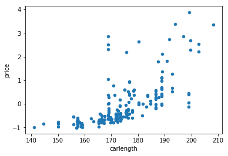

```python
axCarlength = dfFilledNormal.plot.scatter(x='carlength',y='price')
```

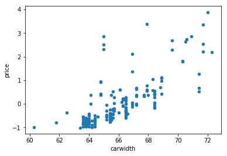

```python
axCarwidth = dfFilledNormal.plot.scatter(x='carwidth',y='price')
```

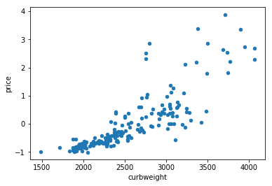

```python
axCurbweight = dfFilledNormal.plot.scatter(x='curbweight',y='price')
```

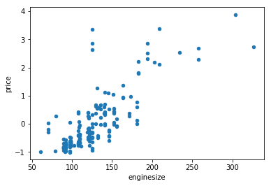

```python
axEnginesize = dfFilledNormal.plot.scatter(x='enginesize',y='price')
```

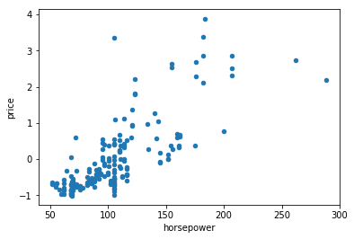

```python
axHorsepower = dfFilledNormal.plot.scatter(x='horsepower',y='price')
```

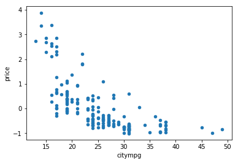

```python
axCitympg = dfFilledNormal.plot.scatter(x='citympg',y='price')
```

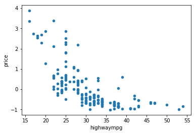

```python
axHighwaympg = dfFilledNormal.plot.scatter(x='highwaympg',y='price')
```

### Part 10-2:

```
Deciding which feature's has the highest correlation with price and is better to be uses
```

I strongly believe that **engine size** would be a great choice because it has the most linear outlook.

## Question 11: Feature selected

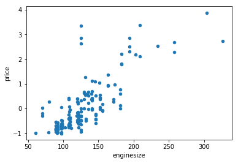

```python
axEnginesize = dfFilledNormal.plot.scatter(x='enginesize',y='price')
```

```python
dfFilledNormalZipped = dfFilledNormal[['enginesize','price']].copy()
```

Here we have to set a hypothesis function like below:

[figure not shown]

so that it would linearly model our regression model so that we would be able to predict the price of cars

# Without sklearn

```python
point_1 = np.where(dfFilledNormal['enginesize'] >= 250)
print("first point desc:")
print(dfFilledNormal.iloc[47])
point_2 = np.where(dfFilledNormal['enginesize'] <= 63)
print("\n\nsecond point desc:")
print(dfFilledNormal.iloc[18])
```

```
first point desc:
car_ID                   48
CarName           jaguar xj
fueltype                  0
carlength             199.6
carwidth               69.6
carheight              52.8
curbweight             4066
cylindernumber          six
enginesize              258
horsepower              176
citympg                  15
highwaympg               19
price               2.28973
Name: 47, dtype: object


second point desc:
car_ID                          19
CarName           chevrolet impala
fueltype                         0
carlength                    141.1
carwidth                      60.3
carheight                     53.2
curbweight                    1488
cylindernumber               three
enginesize                      61
horsepower                 105.747
citympg                         47
highwaympg                      53
price                     -1.00065
Name: 18, dtype: object
```

```python
dfFilledNormal.iloc[18].price
```

```
-1.0006488344592102
```

```python
x0 = dfFilledNormal.iloc[18].enginesize
y0 = dfFilledNormal.iloc[18].price
x1 = dfFilledNormal.iloc[47].enginesize
y1 =  dfFilledNormal.iloc[47].price
m = (y1 - y0)/(x1 - x0)
print("Theta1: ",m)
```

```
Theta1:  0.01670241338191929
```

```python
def hypothesis(engineSize):
    h = m*(engineSize - x0) + y0
    return h
```

Hypothesis test:

```python
print(hypothesis(200))
```

```
1.3209886802030455
```

```python
import math
dfFilledNormalZippedPredicted = dfFilledNormalZipped.copy()
h_theta = dfFilledNormalZipped.copy()
for index, row in dfFilledNormalZippedPredicted.iterrows():
    if math.isnan(row['price']) == True:
        row['price'] = hypothesis(row['enginesize'])
for index, row in h_theta.iterrows():
    row['price'] = hypothesis(row['enginesize'])
```

## Question 12: Calculating MSE of prediced function

```python
h_theta_list = h_theta['price'].tolist()
y = dfFilledNormalZippedPredicted['price'].tolist()
sumOfSquare = 0
for i in range(len(h_theta_list)):
    sumOfSquare = sumOfSquare + ((y[i] - h_theta_list[i])**2)
MSE = sumOfSquare/len(y)
print("Maximum Square Error: ", MSE)
print("Which is less than 0.5")
```

```
Maximum Square Error:  0.3561399942967544
Which is less than 0.5
```

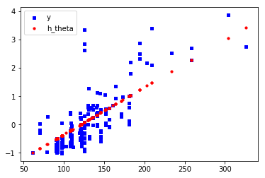

```python
import matplotlib.pyplot as plt

x = dfFilledNormalZippedPredicted['enginesize'].tolist()
fig = plt.figure()
ax1 = fig.add_subplot(111)
ax1.scatter(x, y, s=10, c='b', marker="s", label='y')
ax1.scatter(x, h_theta_list, s=10, c='r', marker="o", label='h_theta')
plt.legend(loc='upper left');
plt.show()
```

We can totaly see that we have predicted a linear hypothesis which fits the input (engine size) to the output (price), in the previous section we saw that the Maximum Square Error of this function is 0.3561399942967544 and is a very suitable function to be used

## Question 14: Final Prediction Fitting

```python
dfWithMissingPricePredicted = dfWithMissingPrice['car_ID'].tolist()
for i in range(len(dfWithMissingPricePredicted)):
    print("Normalized predicted price for viehcle",dfWithMissingPricePredicted[i],"is: ", h_theta_list[dfWithMissingPricePredicted[i]-1])
```

```
Normalized predicted price for viehcle 5 is:  0.2520327411167511
Normalized predicted price for viehcle 30 is:  0.5860814720812182
Normalized predicted price for viehcle 32 is:  -0.4828744670050762
Normalized predicted price for viehcle 53 is:  -0.49957690355329953
Normalized predicted price for viehcle 54 is:  -0.49957690355329953
Normalized predicted price for viehcle 60 is:  0.018198629441624314
Normalized predicted price for viehcle 63 is:  0.018198629441624314
Normalized predicted price for viehcle 68 is:  1.0370472588832487
Normalized predicted price for viehcle 79 is:  -0.4828744670050762
Normalized predicted price for viehcle 85 is:  0.5860814720812182
Normalized predicted price for viehcle 88 is:  -0.1822306091370559
Normalized predicted price for viehcle 89 is:  -0.1822306091370559
Normalized predicted price for viehcle 105 is:  1.003642385786802
Normalized predicted price for viehcle 124 is:  0.018198629441624314
Normalized predicted price for viehcle 137 is:  0.07530172402795854
Normalized predicted price for viehcle 138 is:  0.0014961928934009716
Normalized predicted price for viehcle 142 is:  -0.2156354822335026
Normalized predicted price for viehcle 150 is:  -0.2156354822335026
Normalized predicted price for viehcle 182 is:  0.6695936548223349
Normalized predicted price for viehcle 190 is:  -0.19893304568527925
```

```python
dfWithMissingPricePredicted = dfWithMissingPrice['car_ID'].tolist()
for i in range(len(dfWithMissingPricePredicted)):
    print("predicted price for viehcle",dfWithMissingPricePredicted[i],"is: ", ((h_theta_list[dfWithMissingPricePredicted[i]-1])*stdOfPrice)+meanOfPrice)
```

```
predicted price for viehcle 5 is:  15467.882882928416
predicted price for viehcle 30 is:  18219.054211497452
predicted price for viehcle 32 is:  9415.305960076541
predicted price for viehcle 53 is:  9277.74739364809
predicted price for viehcle 54 is:  9277.74739364809
predicted price for viehcle 60 is:  13542.062952930093
predicted price for viehcle 63 is:  13542.062952930093
predicted price for viehcle 68 is:  21933.13550506565
predicted price for viehcle 79 is:  9415.305960076541
predicted price for viehcle 85 is:  18219.054211497452
predicted price for viehcle 88 is:  11891.36015578867
predicted price for viehcle 89 is:  11891.36015578867
predicted price for viehcle 105 is:  21658.018372208746
predicted price for viehcle 124 is:  13542.062952930093
predicted price for viehcle 137 is:  14012.354805693332
predicted price for viehcle 138 is:  13404.504386501641
predicted price for viehcle 142 is:  11616.243022931769
predicted price for viehcle 150 is:  11616.243022931769
predicted price for viehcle 182 is:  18906.84704363971
predicted price for viehcle 190 is:  11753.80158936022
```

# With sklearn

```python
from sklearn import linear_model
df_train = dfFilledNormalZipped.copy()
reg = linear_model.LinearRegression()
reg.fit(df_train.dropna(thresh=2)[['enginesize']],df_train.dropna(thresh=2).price)
```

```
LinearRegression(copy_X=True, fit_intercept=True, n_jobs=1, normalize=False)
```

```python
print("Theta1: ",reg.coef_)
print("Theta0: ",reg.intercept_)
```

```
Theta1:  [0.02047426]
Theta0:  -2.5691811555114965
```

```python
def hypothesis_reg(engineSize):
    h =  reg.predict(engineSize)
    return h
```

Hypothesis Test

```python
print(hypothesis_reg(200))
```

```
[1.52567025]
```

## Question 12: Calculating MSE of prediced function

```python
dfFilledNormalZippedPredicted_reg = dfFilledNormalZipped.copy()
h_theta_reg = dfFilledNormalZipped.copy()
for index, row in dfFilledNormalZippedPredicted_reg.iterrows():
    if math.isnan(row['price']) == True:
        row['price'] = hypothesis_reg(row['enginesize'])
for index, row in h_theta_reg.iterrows():
    row['price'] = hypothesis_reg(row['enginesize'])
```

```python
h_theta_reg_list = h_theta_reg['price'].tolist()
y = dfFilledNormalZippedPredicted_reg['price'].tolist()
sumOfSquare = 0
for i in range(len(h_theta_list)):
    sumOfSquare = sumOfSquare + ((y[i] - h_theta_list[i])**2)
MSE = sumOfSquare/len(y)
print("Maximum Square Error: ", MSE)
print("Which is less than 0.5")
```

```
Maximum Square Error:  0.35783349503818856
Which is less than 0.5
```

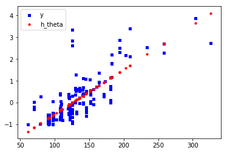

```python
import matplotlib.pyplot as plt

x = dfFilledNormalZippedPredicted_reg['enginesize'].tolist()
fig = plt.figure()
ax1 = fig.add_subplot(111)
ax1.scatter(x, y, s=10, c='b', marker="s", label='y')
ax1.scatter(x, h_theta_reg_list, s=10, c='r', marker="o", label='h_theta')
plt.legend(loc='upper left');
plt.show()
```

## Question 14: Final Prediction Fitting

```python
dfWithMissingPricePredicted_reg = dfWithMissingPrice['car_ID'].tolist()
for i in range(len(dfWithMissingPricePredicted_reg)):
    print("Normalized predicted price for viehcle",dfWithMissingPricePredicted_reg[i],"is: ", h_theta_reg_list[dfWithMissingPricePredicted_reg[i]-1])
```

```
Normalized predicted price for viehcle 5 is:  0.21531779760914072
Normalized predicted price for viehcle 30 is:  0.6248029377739406
Normalized predicted price for viehcle 32 is:  -0.6855495107534182
Normalized predicted price for viehcle 53 is:  -0.7060237677616583
Normalized predicted price for viehcle 54 is:  -0.7060237677616583
Normalized predicted price for viehcle 60 is:  -0.07132180050621884
Normalized predicted price for viehcle 63 is:  -0.07132180050621884
Normalized predicted price for viehcle 68 is:  1.17760787699642
Normalized predicted price for viehcle 79 is:  -0.6855495107534182
Normalized predicted price for viehcle 85 is:  0.6248029377739406
Normalized predicted price for viehcle 88 is:  -0.3170128846050986
Normalized predicted price for viehcle 89 is:  -0.3170128846050986
Normalized predicted price for viehcle 105 is:  1.1366593629799402
Normalized predicted price for viehcle 124 is:  -0.07132180050621884
Normalized predicted price for viehcle 137 is:  -0.0013234244518693927
Normalized predicted price for viehcle 138 is:  -0.09179605751445896
Normalized predicted price for viehcle 142 is:  -0.3579613986215784
Normalized predicted price for viehcle 150 is:  -0.3579613986215784
Normalized predicted price for viehcle 182 is:  0.7271742228151403
Normalized predicted price for viehcle 190 is:  -0.3374871416133387
```

```python
dfWithMissingPricePredicted_reg = dfWithMissingPrice['car_ID'].tolist()
for i in range(len(dfWithMissingPricePredicted_reg)):
    print("predicted price for viehcle",dfWithMissingPricePredicted[i],"is: ", ((h_theta_reg_list[dfWithMissingPricePredicted_reg[i]-1])*stdOfPrice)+meanOfPrice)
```

```
predicted price for viehcle 5 is:  15165.504545442936
predicted price for viehcle 30 is:  18537.957941221
predicted price for viehcle 32 is:  7746.107074731201
predicted price for viehcle 53 is:  7577.484404942296
predicted price for viehcle 54 is:  7577.484404942296
predicted price for viehcle 60 is:  12804.787168398294
predicted price for viehcle 63 is:  12804.787168398294
predicted price for viehcle 68 is:  23090.770025521386
predicted price for viehcle 79 is:  7746.107074731201
predicted price for viehcle 85 is:  18537.957941221
predicted price for viehcle 88 is:  10781.315130931456
predicted price for viehcle 89 is:  10781.315130931456
predicted price for viehcle 105 is:  22753.52468594358
predicted price for viehcle 124 is:  12804.787168398294
predicted price for viehcle 137 is:  13381.282474011667
predicted price for viehcle 138 is:  12636.16449860939
predicted price for viehcle 142 is:  10444.069791353651
predicted price for viehcle 150 is:  10444.069791353651
predicted price for viehcle 182 is:  19381.071290165517
predicted price for viehcle 190 is:  10612.692461142553
```